# BISC 307, Lab 3: Plant Traits & Physiology

We can also visualize the geometric relationships among the variables on both PC1 and PC2 with a biplot:

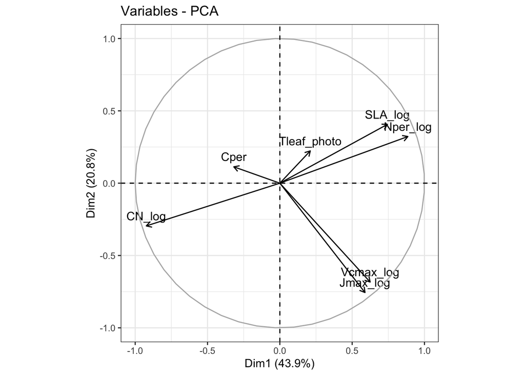

```r
# PCA plot mapping variables in relation to each other on PC1 & PC2
fviz_pca_var(LCE_pca_est,
             geom.ind = "point", # show points only (but not "text")
             mean.point = FALSE, # Remove point that represents the mean of each group
             addEllipses = FALSE, # add ellipses
             col.var = "black") + # make variables & arrows black (default is blue)
  theme_bw()
```

This plots principal component (PC) 1 on the x-axis and PC2 on the y-axis, with the contributions of different variables mapped as arrows. When the arrow is parallel to an axis, it explains variation along that axis, and the longer the arrow, the stronger the relationship.

We can also map points onto a biplot (plot with two PCA axes on the graph axes) with clusters to see if there are differences among a categorical variable in the data, for example phenology (evergreen or deciduous leaves).

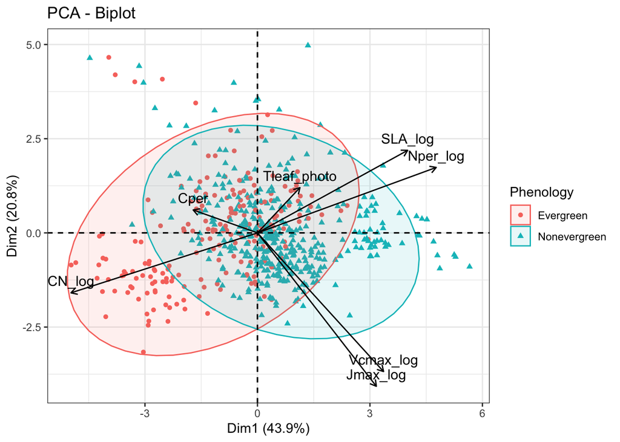

```r
# Plot and color by phenology group
fviz_pca_biplot(LCE_pca_est,
             geom.ind = "point", # show points only (but not "text")
             col.ind = phenology_vector, # color by location
             mean.point = FALSE, # Remove point that represents the mean of each group
             addEllipses = TRUE, # add ellipses
             col.var = "black", # make variables & arrows black (default is blue)
             legend.title = "Phenology")  +
  theme_bw()
```

From this plot we can see that there is a good deal of overlap for the two phenology groups on the PC1-PC2 biplot, but in general there are more evergreen leaf measurements in the negative range of PC1 (high CN ratio) and PC2 (high Jmax, Vcmax) compared to the deciduous group.

**Code Challenge 3: In your group, map a different categorical variable onto the results from the PCA biplot. Are the groups different for the category that you chose? If so, how?**

Let’s work with the example of estimating a linear model with the PC1 axis from the example above as the independent variable, in contrast to including the individual variables for Vcmax, Jmax, percent nitrogen, and the carbon-to-nitrogen ratio. As the response variable, let’s try to capture variation in Rd, the rate of dark respriation. To do this, we’ll need to extract the PC1 axis coordinates that correspond to different data points (this is where the individual data points map onto the PC1 axis).

```r
# Extract PC1 coordinates as a single indpednent variable
# 1. Find the PC1 coordinates for the individual data points
LCE_pca_vars <- get_pca_ind(LCE_pca_est)
LCE_PC1_coord <- LCE_pca_vars$coord[,1]  # First column of coordinates is PC1

# 2. Reattach the PC1 coordinates to the data frame
LCE_pca_coord <- LCE_pca %>%
  mutate(LC1_coord = LCE_PC1_coord,
         Rd_log = Rd_vector)# remove rows with NAs that will conflict with PCA

# Estimate a linear regression model for Rd with PC1
lm_Rd_PC1 <- lm(Rd_log ~ LC1_coord, data = LCE_pca_coord)
summary(lm_Rd_PC1)
```

```
##
## Call:
## lm(formula = Rd_log ~ LC1_coord, data = LCE_pca_coord)
##
## Residuals:
##      Min       1Q   Median       3Q      Max
## -1.90923 -0.25475  0.04051  0.32259  1.28047
##
## Coefficients:
##             Estimate Std. Error t value Pr(>|t|)
## (Intercept)  0.40326    0.01947   20.71   <2e-16 ***
## LC1_coord    0.12373    0.01112   11.12   <2e-16 ***
## ---
## Signif. codes:  0 '***' 0.001 '**' 0.01 '*' 0.05 '.' 0.1 ' ' 1
##
## Residual standard error: 0.4718 on 585 degrees of freedom
## Multiple R-squared:  0.1746, Adjusted R-squared:  0.1732
## F-statistic: 123.8 on 1 and 585 DF,  p-value: < 2.2e-16
```

We can see from the summary output that PC1 fit a significant amount of variation in dark respiration (p < 0.05), and that the R2 for this model is 0.17. The slope is positive, which indicates that thin leaves with high nitrogen tend to have higher rates of dark respiration than thick leaves with a high carbon-to-nitrogen ratio.

This framework can be a helpful and less biased way to incorporate multiple co-varying variables into a linear regression model, since colinearity of response variables violates one of the assumptions of linear regression.

**LAB REPORT INSTRUCTIONS:**

- For your Lab 3 Report, you can investigate a question/hypothesis related to Vcmax, Jmax, and/or Rd that can be tested by the global leaf carbon exchange dataset. You can look at the entire dataset, or a subset (particular sites, particular species, etc.) to formulate/answer your research question.
- As you structure your data analysis to answer your question, produce an .Rmd file pretending that you are starting from scratch (i.e., don’t assume that you have anything loaded from doing the lab exercise). The goal is to be able to hand someone your code and be able to have them re-run your analysis to see what you did and how - this is reproducible research!
- You should `Commit` and `Push` your Rmd file containing your R code and the integrated text for the Lab 3 Report following the Lab Report Guidelines.
- Your Lab 3 Report document must include at least one statistial analysis (ANOVA, linear regression, correlation, or PCA).